# Проверка гипотезы о значимости внесенных изменений

## Задача

Некий параметр изменился в среднем по выборке с 5% до 4,8%. Проверить значимость этого изменения.

## Подход

Рассмотрим два случая в зависимости от природы случайной величины:

- случайная величина имеет [нормальное распределение](https://en.wikipedia.org/wiki/Normal_distribution) (например, проценты - это изменение какого-нибудь ключевого показателя компании);
- случайная величина имеет [распределение Бернулли](https://en.wikipedia.org/wiki/Bernoulli_distribution) (например, рассматривается процент отмен поездок водителем такси).

Для простоты будем считать размеры выборок до и после изменения равны `n`

```r
before_distribution_part <- 0.05
after_distribution_part <- 0.048

std_values <- 0.01 * 2^(seq(0, 8)) # for student's test
```

## Нормальное распределение

В этом случае значимость изменения зависит от дисперсии случайной величины и размера выборок. Рассмотрим значимость в зависимости от этих параметров, считая, что дисперсия нам известна заранее

```r
result_student <- data.frame()

for (n in seq(1, 100000, 100)) {
  for (dist_std in std_values) {
    z <- (before_distribution_part - after_distribution_part) * ((2 * dist_std ^ 2) / n)^(-1/2)
    result_student <- result_student %>%
      bind_rows(
        data.frame(n = n, z = z, p.value = (1 - pnorm(z, 0, 1)) * 2, dist_std = dist_std)
      )
  }
}
```

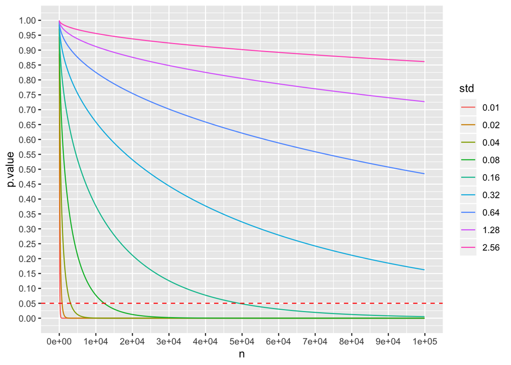

```r
ggplot(result_student) +
  geom_line(aes(x = n, y = p.value, color = as.factor(dist_std))) +
  geom_hline(yintercept = 0.05, color = 'red', linetype = 'dashed') +
  scale_y_continuous(breaks = seq(0, 1, 0.05)) +
  scale_x_continuous(breaks = seq(0, 100000, 10000)) +
  scale_color_discrete(name = 'std')
```

### Пример проверки гипотезы (нормальное распределение)

Мы имеем следующий датасет:

```r
data_norm <- read.csv('data_norm.csv')

head(data_norm)
```

```
##   trip_id    feature period
## 1       0 0.04402347 before
## 2       1 0.03787196 before
## 3       2 0.05046686 before
## 4       3 0.08016472 before
## 5       4 0.07923912 before
## 6       5 0.03801651 before
```

В нем 1000 наблюдений в период ДО изменения и 1000 - в период ПОСЛЕ.

**Задача** - определить значимо ли это изменение.

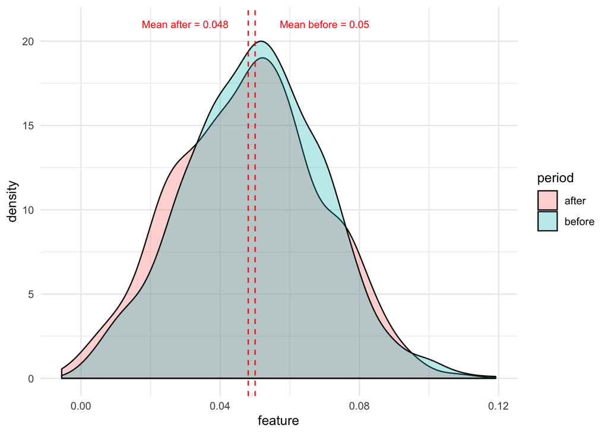

```r
data_before <- data_norm %>% filter(period == 'before')
data_after <- data_norm %>% filter(period == 'after')

mean_before <- mean(data_before$feature)
mean_after <- mean(data_after$feature)

data_norm %>% ggplot(aes(x = feature, fill = period)) +
  geom_density(alpha = 0.3) +
  geom_vline(xintercept = mean_before, color = 'red', linetype = 'dashed') +
  geom_vline(xintercept = mean_after, color = 'red', linetype = 'dashed') +
  annotate('text', x = 0.07, y = 21, label = paste0('Mean before = ', round(mean_before, 3)),
           color = 'red', size = 3) +
  annotate('text', x = 0.03, y = 21, label = paste0('Mean after = ', round(mean_after, 3)),
           color = 'red', size = 3) +
  theme_minimal()
```

Средние выборок отличаются. Посмотрим на стандартное отклонение.

```r
print(paste0('sd = ', round(sd(data_norm$feature), 2)))
```

```
## [1] "sd = 0.02"
```

Для решения задачи применим [тест Стьюдента](https://en.wikipedia.org/wiki/Student%27s_t-test) и оценим статистическую значимость (α = 0.05).

```r
t.test(data_before$feature, data_after$feature)
```

```
##
##  Welch Two Sample t-test
##
## data:  data_before$feature and data_after$feature
## t = 2.1694, df = 1993.1, p-value = 0.03017
## alternative hypothesis: true difference in means is not equal to 0
## 95 percent confidence interval:
##  0.0001882836 0.0037350663
## sample estimates:
##  mean of x  mean of y
## 0.05003201 0.04807034
```

**p-value < α**, следовательно мы отвергаем [нулевую гипотезу](https://en.wikipedia.org/wiki/Null_hypothesis) о равенстве двух средних генеральной совокупности. **Вывод** - наблюдаемые изменения статистически **значимы**.

## Распределение Бернулли

В этом случае только размер выборок влияет на значимость

```r
result_fisher <- data.frame()

for (n in seq(1, 100000, 100)) {

  pos_before_n <- round(before_distribution_part * n)
  pos_after_n <- round(after_distribution_part * n)

  con_table <- matrix(
    c(pos_before_n, pos_after_n, n - pos_before_n, n - pos_after_n),
    nrow = 2,
    dimnames = list(group = c("Before", "After"), param = c("Pos", "Neg"))
  )

  test_res <- fisher.test(con_table)

  result_fisher <- result_fisher %>%
    bind_rows(
      data.frame(n = n, p.value = test_res$p.value)
    )
}
```

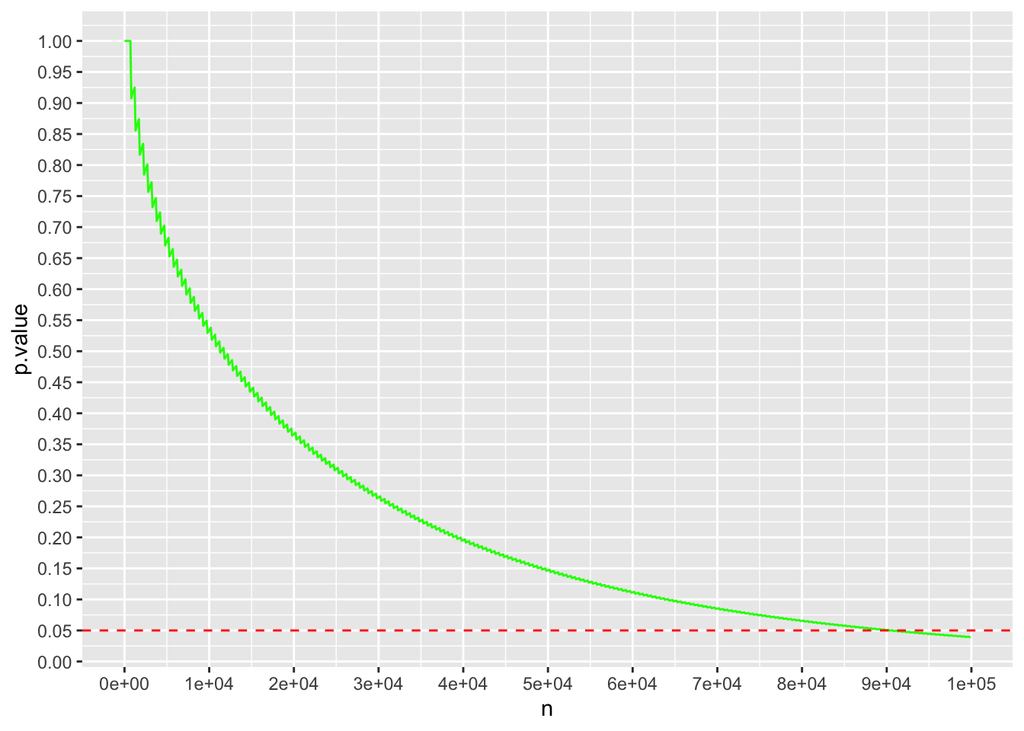

```r
ggplot(result_fisher) +
  geom_line(aes(x = n, y = p.value), color = 'green') +
  geom_hline(yintercept = 0.05, color = 'red', linetype = 'dashed') +
  scale_y_continuous(breaks = seq(0, 1, 0.05)) +
  scale_x_continuous(breaks = seq(0, 100000, 10000))
```

Изменение значимо если размер выборок до и после изменения больше 90 000.

### Пример проверки гипотезы (распределение Бернулли)

```r
data_raw <- read.csv('data_bern.csv')

data_prep <- data_raw %>%
  mutate(group = ifelse(dt %in% c("2018-11-20","2018-11-21"), 'before', 'after'))

data_group <- data_prep %>%
  group_by(group) %>%
  summarise(
    count = n(),
    feature = round(mean(is_view) * 100, 2)
  )
```

Мы имеем следующий датасет, длиной 4520 строчек:

```r
head(data_raw)
```

```
##           dt user_id is_view
## 1 2018-11-20  108548       0
## 2 2018-11-20  113151       0
## 3 2018-11-20  121937       0
## 4 2018-11-20  239444       0
## 5 2018-11-20  352728       0
## 6 2018-11-20  500709       0
```

В нем находится информация по четырем дням, первые два из которых - период “до”, вторые - период “после”. Между этими датами произошло некоторое *изменение*.

```r
kable(data_group) %>% kable_styling(full_width = F, position = "center")
```

| group | count | feature |
| --- | --- | --- |
| after | 2260 | 4.82 |
| before | 2260 | 5.04 |

Мы видим, что значение признака после изменения снизилось на 0,22%. **Задача** - определить значимо ли это изменение.

Для решения задачи применим [тест Фишера](https://en.wikipedia.org/wiki/Fisher%27s_exact_test), построив таблицу сопряженности для нашего распределения Бернулли и оценим статистическую значимость наблюдаемых данных (α = 0.05).

```r
data_before <- data_prep %>% filter(group == 'before')
data_after <- data_prep %>% filter(group == 'after')

pos_before <- sum(data_before$is_view)
pos_after <- sum(data_after$is_view)
n <- length(data_before$is_view)

con_table <- matrix(
  c(pos_before, pos_after, n - pos_before, n - pos_after),
  nrow = 2,
  dimnames = list(group = c("Before", "After"), param = c("Pos", "Neg"))
)

test_res <- fisher.test(con_table)
p_value <- test_res$p.value
```

Таблица сопряженности:

|  | Pos | Neg |
| --- | --- | --- |
| Before | 114 | 2146 |
| After | 109 | 2151 |

```r
print(paste0('p-value = ', round(p_value, 3)))
```

```
## [1] "p-value = 0.784"
```

Рассчитанное p-value > α, поэтому у нас нет оснований для того, чтобы отвергнуть нулевую гипотезу. **Вывод** - наблюдаемые изменения статистически **не значимы**.